# Flight_prices_analysis slides

#### Lasso

```python
model = Lasso(alpha=2)
model.fit(X_train, y_train)
print(model.score(X_train, y_train))
print(model.score(X_test, y_test))
```

```
0.42796606130018805
-0.24890728565905282
```

Now, I try to visualize the predictions and compare them to the real price values:

```python
predictions_train = model.predict(X_train)
predictions_test = model.predict(X_test)

X['predictions'] = np.concatenate([predictions_train,predictions_test])
```

```python
X['predictions'].plot(figsize=(12,5))
y.plot()
plt.vlines(X.index[n],0,280)
plt.show()
```

[output not shown]

```python
X['predictions'][n-20:n].plot(figsize=(12,5))
y[n-20:n].plot()
plt.vlines(X.index[n],0,120)
plt.show()
```

[output not shown]

```python
fig, ax = plt.subplots()
X['predictions'][n:].plot(figsize=(12,5))
y[n:].plot()
plt.vlines(X.index[n],0,280)
ax.legend(('Predictions','Real Prices'))
plt.show()
```

[output not shown]

#### Random Forest Regressor

```python
model = RandomForestRegressor(n_estimators=100)
model.fit(X_train, y_train)
print(model.score(X_train, y_train))
print(model.score(X_test, y_test))
```

```
0.928051997514165
-0.6193376033927447
```

Now, I try to visualize the predictions and compare them to the real price values:

```python
predictions_train = model.predict(X_train)
predictions_test = model.predict(X_test)

X['predictions'] = np.concatenate([predictions_train,predictions_test])
```

```python
X['predictions'].plot(figsize=(12,5))
y.plot()
plt.vlines(X.index[n],0,280)
plt.show()
```

[output not shown]

```python
fig, ax = plt.subplots()
X['predictions'][n:].plot(figsize=(12,5))
y[n:].plot()
plt.vlines(X.index[n],0,280)
ax.legend(('Predictions','Real Prices'))
plt.show()
```

[output not shown]

```python
LGW_1 = pd.DataFrame()

LGW_1['Iberia']=LGW[LGW['airline']=='Iberia'].groupby('date')['price'].mean().diff()
LGW_1['Norwegian']=LGW[LGW['airline']=='Norwegian'].groupby('date')['price'].mean().diff()
LGW_1['Easyjet']=LGW[LGW['airline']=='Easyjet'].groupby('date')['price'].mean().diff()
LGW_1['Air Europa']=LGW[LGW['airline']=='Air Europa'].groupby('date')['price'].mean().diff()
```

I include the day of the week as well:

LGW_1['Monday']=LGW.groupby('date')['Monday'].min() LGW_1['Tuesday']=LGW.groupby('date')['Tuesday'].min() LGW_1['Wednesday']=LGW.groupby('date')['Wednesday'].min() LGW_1['Thursday']=LGW.groupby('date')['Thursday'].min() LGW_1['Friday']=LGW.groupby('date')['Friday'].min() LGW_1['Saturday']=LGW.groupby('date')['Saturday'].min() LGW_1['Sunday']=LGW.groupby('date')['Sunday'].min()

Failure, didn't work

```python
LGW_1['Air Europa'].mean()
```

[output not shown]

```python
fig,ax = plt.subplots(figsize=(12,5))
LGW_1[['Iberia','Norwegian','Easyjet','Air Europa']].diff().plot(ax=ax)
plt.show()
```

[output not shown]

```python
X = LGW_1.copy()
y = X.pop('Air Europa')
X.dropna(inplace=True)
y = y[1:]
X.head(3)
```

[output not shown]

```python
X.shape
```

[output not shown]

```python
## we divide our dataset into part2 (the part in which we have available Air Europa prices, our y),
# and part3 (no Air Europa prices, no y)
y2 = y[:155]
X2 = X[:155]
y3 = y[155:]
X3 = X[155:]
```

```python
y2 = y2.fillna(method='ffill')
X2 = X2.fillna(method='ffill')
```

```python
n = round((y2.shape[0])*0.30)
X_train, y_train = X2[:n], y2[:n]
X_test, y_test = X2[n:], y2[n:]
```

```python
model_lr = LinearRegression()
model_lr.fit(X_train, y_train)
print(model_lr.score(X_train, y_train))
print(model_lr.score(X_test, y_test))
```

[output not shown]

```python
model = ElasticNet(alpha=800)
model.fit(X_train, y_train)
print(model.score(X_train, y_train))
print(model.score(X_test, y_test))
```

[output not shown]

```python
model_rfr = RandomForestRegressor(n_estimators=100)
model_rfr.fit(X_train, y_train)
print(model_rfr.score(X_train, y_train))
print(model_rfr.score(X_test, y_test))
```

[output not shown]

```python
X3_lr = list(model_lr.predict(X3))
X3_rfr = list(model_rfr.predict(X3))
```

```python
X3['Air Europa lr'] = X3_lr
X3['Air Europa rfr'] = X3_rfr
```

```python
fig,ax = plt.subplots(figsize=(12,5))
X3[['Air Europa lr','Air Europa rfr']].plot(ax=ax)
plt.show()
```

[output not shown]

### Predicting prices for one airline using prices of other airlines

#### Predicting Air Europa prices for the rest of the year

```python
LGW2 = pd.DataFrame()
LGW2['Iberia']=LGW[LGW['airline'] == 'Iberia'].groupby('date')['price'].min()
LGW2['Air Europa']=LGW[LGW['airline'] == 'Air Europa'].groupby('date')['price'].min()
LGW2['Easyjet']=LGW[LGW['airline'] == 'Easyjet'].groupby('date')['price'].min()
LGW2['Norwegian']=LGW[LGW['airline'] == 'Norwegian'].groupby('date')['price'].min()
```

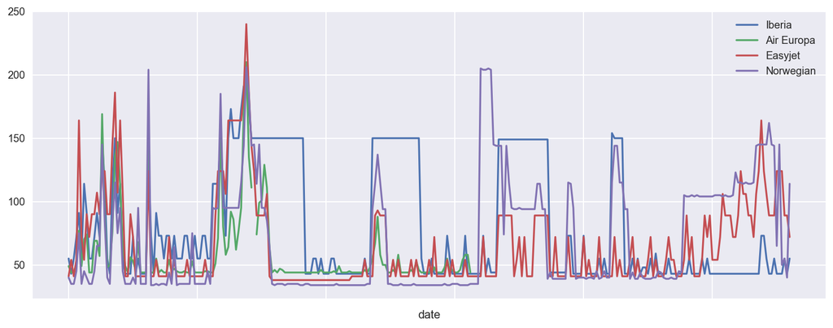

```python
fig,ax = plt.subplots(figsize=(12,5))
LGW2.plot(ax=ax);
```

```python
LGW2 = LGW2.fillna(method='ffill')
X = LGW2[['Easyjet','Air Europa','Norwegian','Iberia']].copy()
y = X.pop('Air Europa')
X.head(3)
```

| date | Easyjet | Norwegian | Iberia |
| --- | --- | --- | --- |
| 2018-10-01 | 41 | 40 | 55 |
| 2018-10-02 | 54 | 35 | 43 |
| 2018-10-03 | 41 | 35 | 55 |

```python
# we divide our dataset into part1 (the part in which we have available Air Europa prices, our y),
# and part2 (no Air Europa prices, no y)
y1 = y[:156]
X1 = X[:156]
y2 = y[156:]
X2 = X[156:]
```

```python
n = round((y1.shape[0])*0.4)
X_train, y_train = X1[:n], y1[:n]
X_test, y_test = X1[n:], y1[n:]
```

```python
model = LinearRegression()
model.fit(X_train, y_train)
print(model.score(X_train, y_train))
print(model.score(X_test, y_test))
```

```
0.7672542757469313
0.5943773396799437
```